# Análisis de la serie temporal

## Componentes de la serie temporal

Es frecuente analizar las series temporales desde el punto de vista de sus componentes estructurales: *Serie observada = Tendencia + Efecto estacional + Residuos*.

Si queremos que **R** trate un objeto como una serie temporal, tenemos que determinar apropiadamente sus características con el comando *ts*. Para definir la serie correctamente escribimos:

```r
ts <- ts(data$demand, frequency = 24*60/10)
```

El argumento *frequency* se utiliza para indicar la periodicidad de la serie (en este caso de 10 minutos).

### Análisis de autocorrelación y autocorrelación parcial

El análisis de correlación y autocorrelación parcial se usa para examinar la dependencia de la serie.

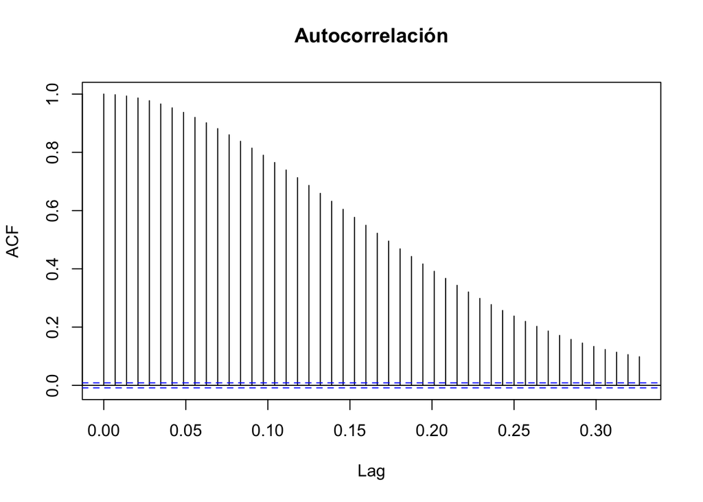

```r
acf(ts, main = "Autocorrelación")
```

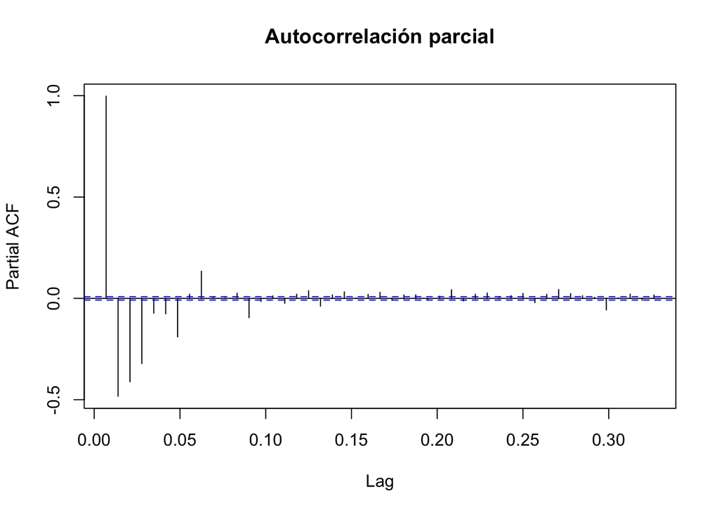

```r
pacf(ts, main = "Autocorrelación parcial")
```